# From Knockout to Nocáut

The Use of Anglicisms in Revista Estadio 1942-1982

Author

Hernán Adasme

Published

May 15, 2023

# 1 **Introduction**

## 1.1 **The Source and its Context: Revista Estadio 1941-1982**

In the mid-twentieth century, the weekly publication Revista Estadio marked a turning point in the history of sports tabloids in Chile. Before it, specialized sporting magazines had been mostly short lived enterprises, struggling to remain in circulation, and suffering from chronic financial insolvency. Revista Estadio managed to secure a place in the Chilean printing industry, by bringing together an intense graphic style, with a diversity of content that included straight-lead game descriptions, season previews and wrap-up stories, chronicles and columns[^1]. The ethos of the magazine aligned with the developmentalist and modernizing strategy championed by the Frente Popular governments, between 1936-1941, and with the increasing role played by the state in the economy, society and culture in the mid twentieth-century[^2]. Estadio crafted a vision that emphasized national sentiments, the centrality of sports to Chilean identity and the values of male domesticity and manhood. In its 40 years of existence, Estadio was able to remain in circulation throughout a dramatic political cycle that witnessed the rise and fall of the developmental state, the democratization and political mobilization of Chilean society, the breakdown of the democratic regime and the first ten years of Pinochet’s authoritarian rule. Since the 1990s, a growing body of research has explored Revista Estadio’s connection with 1940’s Latin American populism and developmentalist strategies[^3], its role in supporting middle class reform and upward mobility in the 1940s and 1950s, and its relevance as a cultural medium reproducing narratives of racial unity, masculinity and male citizenship[^4].  
By analyzing the frequency and usage of anglicisms in a timespan of 40 years, this study aims to explore a textual and linguistic angle of the globalization of sports. The use, adaptation, and transformation of English sporting specialized terminology overtime is a historically situated process, as well as a linguistic phenomenon. English provided the nomenclature that accompanied the emergence of a myriad of social relationships brought by the massification of sports. Since the anglophone sports lexical set retained important variations depending on the athletic discipline, and the social class of its practitioners and audiences, anglicisms are a window to the interaction between social classes, institutions, knowledge producers, audience and the mass media. English specialized vocabularies are markers of an increasing transnational process of cultural and economic interaction. From the mid-nineteenth century onwards, anglicisms have been continuously transferred from the English-speaking world into areas such as technology, science, communications, mass culture, and sports, a process that “evoke[s] the hegemony of Anglo- Saxon countries, especially the United States, in the international community”[^5]. In Chile and Latin America, the explosion of anglophone sporting vocabulary signals a process of rapid urbanization that gave way to the commodification and massification of modern sports. As transnational mass culture interacted and combined with local popular cultures, English terminologies entered, remained and negotiated their way into Spanish language until today.

<sup>1</sup> Eduardo Santa Cruz, Imagen de Chile, 115

<sup>2</sup> Eduardo Santa Cruz, Prensa deportiva y desarrollismo en Chile: el caso de la revista Estadio”, revista Mapocho, [n° 71](http://www.memoriachilena.gob.cl/602/w3-article-124019.html), 2012

<sup>3</sup> Pedro Acuña, Playing across the andes: Sports media and populism in Argentina and Chile. Journal of Latin American Studies. 2019;51(4):855-882.

<sup>4</sup> Santa Cruz, Prensa y Sociedad en Chile, Siglo XX. For a detailed study of the link between masculinity and sports in Chile see Brenda Elsey, Sportsman and Citizens.

<sup>5</sup> Anglicisms in Contemporary Spanish: an overview.

## 1.2 **Methodology**

The methodology of this study is quite straightforward: counting English words in a corpus of forty years of publications of Revista Estadio, with the help of computational methods. The goal is to analyze the frequencies of anglicism usage in order to discover hidden patterns in lexical borrowing overtime, and analyze the results against an historical background. As Kellen Funk and Lincoln Mullen rightly suggest, Text Analysis methods are “most useful when mixed with more traditional approaches for forming historical questions and reading historical evidence.”[^6] Was the use of borrowed lexicon affected by nationalists’ views attached to the practice of sports? Do changes in the use of english terms relate with the professionalization of sports journalism, and different trends in the commodification and commercialization of sports? Those questions frame the exploration of English vocabulary not only for the realm of sports media, but also for a wider array of transnational circulations of knowledge between the English and the non-English world.

<sup>6</sup> Kellen Funk, Lincoln A. Mullen, "The Spine of American Law: Digital Text Analysis and U.S. Legal Practice", The American Historical Review, Volume 123, Issue 1, February 2018, Pages 132–164, 144 https://doi.org/10.1093/ahr/123.1.132

Although straightforward on its methods, setting this project up involved a considerable amount of data preparation. Curating the corpus required several data transformations, from the original pdf files available in www.memoriachilena.cl, a virtual library supported by Chile’s Dirección de Bibliotecas, Archivos y Museos, to the construction of datasets. The data was constructed using a trimestral sample of the published numbers per each year, from 1942 to 1982. The transformation involved the construction of an infrastructure in python to transform, clean, preprocess, and scrutinize the texts, preserving their location in the historical timeline. By closely reading the magazine, I selected 46 English terms and its Spanish equivalents -mostly nouns and some verbs-, and tracked their frequencies. The results were stored in independent python dictionaries, and then transformed into two types of dataframes: one with the raw frequencies, and another with a ratio of usage, that is, the english frequency normalized against the spanish term plus the english term. From there, the frequencies and ratios are analyzed in general, and by following the historical movement of a set of relevant terms.

# 2 **From Knockout to Nocaut**

*“And the regrettable eagerness to use these foreign words in sports language has reached such extremes in Chile that fans of this kind of entertainment, from the great sports journalists of the newspapers to the modest working class child who can barely push a ball, have a truly overwhelming vocabulary of foreign technical words”*

Rodolfo Oroz, *El Castellano de Nuestros Deportistas* (The Spanish of our Athletes), 1927

<sup>7</sup> Lidia Contreras, 179

The fear of blemishing Spanish through the use of foreign words was longstanding. In 1927, the philologist Rodolfo Oroz, pointed out that English words “represent a foreign body in our vocabulary, no matter how much it is said that these are generally accepted words.”[^8] In the nineteenth century, the salesian priest and lexicographer Camilo Ortuzar considered the use of foreign words as “noxious weeds of our language”[^9]. In the same volume, Ortúzar rejected the use of the word meeting in Chilean Spanish as “unbridled Anglicism that spreads and prevails like everything bad”[^10]. In the mid-twentieth century, both Argentina’s Peronist Populist Regime and Spain’s Franquist Regime, placed limitations on the use of foreign terminology in the media, and tried to castellanize imported lexicon, in order to boost nationalists agendas[^11].

<sup>8</sup> Rodolfo Oroz, El Castellano de Nuestros Deportistas

<sup>9</sup> Camilo Ortuzar, Diccionario manual de locuciones viciosas y de correcciones de lenguaje: con indicación del valor de algunas palabras y ciertas nociones gramaticales,107

<sup>10</sup> Camilo Ortuzar, 210

<sup>11</sup> Rodríguez González, Francisco. “Variaciones en el uso de anglicismos deportivos.” (2007).

None of these apprehensions seemed to have prevented sports journalists from massively turning to a foreign technical terminology. Although nineteenth-century elites educated in Europe were inclined to import Gallicisms, the massification of sports, and the strong presence of athletics, leisure and technology in the press and radio broadcasting, turned the use of anglicisms into a widespread practice across social classes. Between 1900 and 1942, more than 30 sporting magazines and tabloids were published intermittently in Chile’s most populated cities.[^12] Since 1910, when sports were definitely becoming a commercialized commodity, traditional newspapers boosted their sections on deporte, whose topics became independent from social life and leisure[^13].

<sup>12</sup> Some of these magazines had English names like Crack(1937), Los Sports(1923), El Ring (1917), Match(1928). For a detailed account see Eduardo Santa Cruz, Prensa, espacio público y modernización: las revistas deportivas en Chile (1900-1950), 2012, Alex Ovalle, El Viril Deporte, Boxeo, Modernización y Cultura de Masas (1904-1931), Centro de Estudios Bicentenario.

<sup>13</sup> Vásquez Amador, María, Lario, Carmen, & López, Paloma. (2015). Los anglicismos en la prensa deportiva de los 50. Estudios filológicos, (55), 157-176. https://dx.doi.org/10.4067/S0071-17132015000100010

For Chilean sports writers and editors, and especially for Revista Estadio, promoting the sport was endowed with a nationalist and modernizing aura, regardless of the language. The press supported sports as a national crusade against alcoholism, gambling and prostitution. They also sought to use athleticism to promote middle-class values, reinforce the concept of male domesticity, and even restrain revolutionary labor movements[^14]. The use of a foreign jargon terms evoked modernity and had an aura of scientificism, as sportswriters demonstrated their erudition, and put forward the idea that sports could be conducted in a “technical” way. In some cases, the compromise of journalists and editors with the modernizing promise of sports went beyond the printed word, as some of them became club representatives, sports organization’s managers, and social reformers.

<sup>14</sup> See Oscar Peñafiel, Hernán Adasme

The increase in anglicism usage led to a proliferation of their variations. Sportswriters’ knowledge of English wasn’t always beyond a rudimentary level, which created a sheer diversity among neologisms originated in lexical borrowings. The proliferation of printers’ typographic errors, overcorrection by editors, and the process of hybridization and castellanization - which involves using the phonetic structure of Spanish to transform foreign words - have resulted in a vast array of variants for semantically related terminologies. These variants were especially noticeable in the discipline names -such as basketball and volleyball- and in verbs like *to shoot* or *to dribble*.[^15]

<sup>15</sup> The variants included basquetball, basketbol, basquetbol, basketbal, among others

<sup>16</sup> This created several issues like the word team being extracted from the word norteamericano. To solve this I simply eliminated all the words that were creating these problems. Prior to tokenizing words, I created several functions to clean up the text and separate as many words as I could. Capital words and Spanish accent marks were crucial to split words apart

Boxing Challenges: a historical view

A public boxing challenge was an invitation to arrange a fight for a prize, launched by a boxer to a potential contender through a newspaper. Challenges usually consisted of three steps: a boxer or his manager publishing the challenge; the defied pugilist responding through the press; and both parts coming to an agreement about the conditions of the bout. Throughout the 1920s, any boxer –no matter how advanced in his career, and regardless of his skills as a pugilist– could challenge another fighter to a boxing bout. In the majority of the cases, publishing a challenge aimed to arrange a commercialized boxing match, although in some instances it would merely concert fighters for an entirely amateur encounter. Since pro boxers had a machinery for the concentration of fights, the highly formatted boxing challenge that we care about was a mode of communication used during the 1920s mostly by newcomers, rookie boxers, amateur fighters and, in general, by athletes exploring the opportunity to start a career.

```python
import re
import numpy as np
import pickle
import pandas as pd
import matplotlib.pyplot as plt
import seaborn as sns
```

```python
pd.set_option('display.max_columns', None)
df_freq_1942_1982 = pd.read_csv(r'/Users/hernanadasme/Projects/estadio_1940_1980/csv/df_intindex_1942_1982.csv', sep=',', index_col = 0)
df_freq_1942_1982.head()
#creating another copy with a selection of columns
df_less = df_freq_1942_1982.drop(columns=['centroforward', 'line','centerforward', 'teams', 'shortstop', 'pitchers', 'catch'])
df_less.head()
```

|  | fighter | training | chance | sprinter | ring | lineman | forward | tackle | shot | kick | out | single | crack | referee | sport | boxing | player | standard | knockout | score | team | elgoal | jersey | coach | handicap | dribbling | record | shoot | back | … |
| --- | --- | --- | --- | --- | --- | --- | --- | --- | --- | --- | --- | --- | --- | --- | --- | --- | --- | --- | --- | --- | --- | --- | --- | --- | --- | --- | --- | --- | --- | --- |
| 1942 | 1 | 4 | 34 | 20 | 121 | 0 | 32 | 0 | 23 | 0 | 30 | 27 | 244 | 7 | 87 | 8 | 34 | 20 | 1 | 107 | 657 | 5 | 3 | 15 | 5 | 5 | 292 | 3 | 58 | … |
| 1943 | 11 | 2 | 48 | 27 | 156 | 3 | 40 | 1 | 36 | 4 | 27 | 29 | 455 | 30 | 81 | 0 | 92 | 10 | 5 | 114 | 293 | 3 | 2 | 12 | 4 | 3 | 339 | 1 | 47 | … |
| 1944 | 3 | 4 | 52 | 39 | 156 | 0 | 67 | 10 | 23 | 3 | 22 | 36 | 276 | 33 | 94 | 1 | 64 | 17 | 7 | 92 | 355 | 2 | 0 | 21 | 24 | 11 | 276 | 2 | 53 | … |
| 1945 | 7 | 3 | 53 | 16 | 237 | 1 | 75 | 0 | 17 | 2 | 53 | 24 | 221 | 63 | 114 | 0 | 87 | 18 | 16 | 135 | 410 | 2 | 2 | 37 | 17 | 18 | 356 | 4 | 50 | … |
| 1946 | 0 | 3 | 41 | 5 | 198 | 0 | 86 | 0 | 23 | 0 | 27 | 39 | 117 | 55 | 68 | 2 | 54 | 20 | 7 | 115 | 494 | 0 | 13 | 19 | 23 | 12 | 305 | 0 | 31 | … |

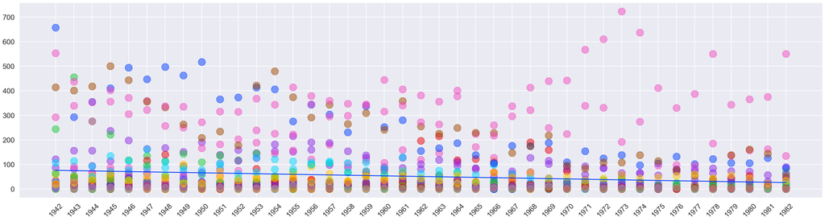

Figure 1: Raw frecuencies of the use of anglicisms between 1942-1982

```python
fig, ax = plt.subplots(figsize=(40, 10))
for column in df_less.columns:
    ax.scatter(df_less.index, df_less[column], label=column, s=400, alpha = 0.5)

sns.set_style('darkgrid')
sns.set_palette('bright')
sns.set_context('talk')

# compute the trend line for the selected columns
x = df_less.index.values
y = df_less.values
m, b = np.polyfit(x, y.mean(axis=1), 1)

# add the trend line to the plot
ax.plot(x, m*x + b, label='Trend line')

#ax.legend()
#ax.set_xlabel('Document')
#ax.set_ylabel('Frequency')
ax.set_xticks(df_less.index)
plt.yticks(fontsize=20)
plt.xticks(rotation=45, fontsize=20)
#plt.legend(fontsize='20')
plt.show()
```